# Basic read and slice with Xibabel

```python
from pathlib import Path

import xibabel as xib

import matplotlib.pyplot as plt
plt.rc('image', cmap='gray')
```

from pathlib import Path import xibabel as xib import matplotlib.pyplot as plt plt.rc('image', cmap='gray')

We can load images directly from web URLs:

```python
ximg = xib.load('https://s3.amazonaws.com/openneuro.org/ds000105/sub-1/func/sub-1_task-objectviewing_run-01_bold.nii.gz')
ximg
```

ximg = xib.load('https://s3.amazonaws.com/openneuro.org/ds000105/sub-1/func/sub-1_task-objectviewing_run-01_bold.nii.gz') ximg

```
<xarray.DataArray 'sub-1_task-objectviewing_run-01_bold' (i: 40, j: 64, k: 64,
                                                          time: 121)> Size: 159MB
dask.array<array, shape=(40, 64, 64, 121), dtype=float64, chunksize=(40, 64, 64, 121), chunktype=numpy.ndarray>
Coordinates:
  * i        (i) int64 320B 0 1 2 3 4 5 6 7 8 9 ... 31 32 33 34 35 36 37 38 39
  * j        (j) int64 512B 0 1 2 3 4 5 6 7 8 9 ... 55 56 57 58 59 60 61 62 63
  * k        (k) int64 512B 0 1 2 3 4 5 6 7 8 9 ... 55 56 57 58 59 60 61 62 63
  * time     (time) float64 968B 0.0 2.5 5.0 7.5 ... 292.5 295.0 297.5 300.0
Attributes:
    RepetitionTime:  2.5
    xib-affines:     {'scanner': [[-3.5, 0.0, 0.0, 68.25], [0.0, 3.75, 0.0, -...
```

Notice that loading automatically picks up BIDS data in corresponding JSON files:

```python
ximg.attrs
```

ximg.attrs

```
{'RepetitionTime': 2.5,
 'xib-affines': {'scanner': [[-3.5, 0.0, 0.0, 68.25],
   [0.0, 3.75, 0.0, -118.125],
   [0.0, 0.0, 3.75, -118.125],
   [0.0, 0.0, 0.0, 1.0]]}}
```

Slicing can now use axis labels:

```python
mean_img = ximg.mean('time')
mean_img
```

mean_img = ximg.mean('time') mean_img

```
<xarray.DataArray 'sub-1_task-objectviewing_run-01_bold' (i: 40, j: 64, k: 64)> Size: 1MB
dask.array<mean_agg-aggregate, shape=(40, 64, 64), dtype=float64, chunksize=(40, 64, 64), chunktype=numpy.ndarray>
Coordinates:
  * i        (i) int64 320B 0 1 2 3 4 5 6 7 8 9 ... 31 32 33 34 35 36 37 38 39
  * j        (j) int64 512B 0 1 2 3 4 5 6 7 8 9 ... 55 56 57 58 59 60 61 62 63
  * k        (k) int64 512B 0 1 2 3 4 5 6 7 8 9 ... 55 56 57 58 59 60 61 62 63
```

Notice that we haven't yet fetched the data. We do so only when we need it - for example, when plotting the image data:

```python
plt.imshow(mean_img.sel(k=32))
```

plt.imshow(mean_img.sel(k=32))

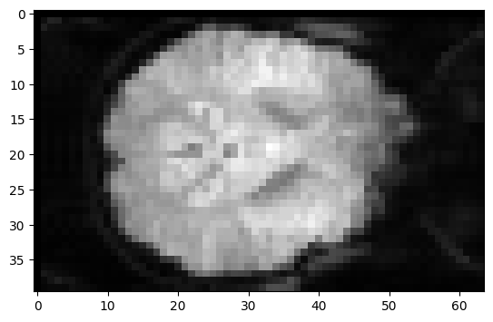

We may also want to get a local in-memory copy of the image so we don't have to do repeated reads from the source:

```python
ximg_loaded = ximg.compute()
ximg_loaded
```

ximg_loaded = ximg.compute() ximg_loaded

```
<xarray.DataArray 'sub-1_task-objectviewing_run-01_bold' (i: 40, j: 64, k: 64,
                                                          time: 121)> Size: 159MB
array([[[[ 0.,  0.,  0., ...,  0.,  0.,  0.],
         [ 0.,  0.,  0., ...,  0.,  0.,  0.],
         [ 0.,  0.,  0., ...,  0.,  0.,  0.],
         ...,
         [ 0.,  0.,  0., ...,  0.,  0.,  0.],
         [ 0.,  0.,  0., ...,  0.,  0.,  0.],
         [ 0.,  0.,  0., ...,  0.,  0.,  0.]],

        [[ 9.,  0.,  0., ..., 14., 11., 17.],
         [14.,  0.,  0., ..., 17.,  8., 15.],
         [27.,  0.,  0., ..., 10., 13., 10.],
         ...,
         [ 0.,  0.,  0., ...,  0.,  0.,  0.],
         [ 0.,  0.,  0., ...,  0.,  0.,  0.],
         [ 0.,  0.,  0., ...,  0.,  0.,  0.]],

        [[ 7.,  0.,  0., ..., 11.,  9., 11.],
         [14.,  0.,  0., ...,  9., 10., 17.],
         [29.,  0.,  0., ..., 13.,  9., 13.],
         ...,
...
         ...,
         [17., 15., 15., ..., 16., 11., 11.],
         [11., 15., 12., ..., 11., 13., 13.],
         [ 8., 10.,  6., ...,  7.,  9.,  7.]],

        [[ 0.,  0.,  0., ...,  0.,  0.,  0.],
         [13.,  5., 14., ..., 11., 11.,  9.],
         [15.,  8.,  9., ..., 12., 17., 17.],
         ...,
         [16., 17., 18., ..., 15., 11., 16.],
         [14., 13., 17., ..., 18.,  9., 10.],
         [10.,  8.,  8., ...,  9.,  9.,  5.]],

        [[ 0.,  0.,  0., ...,  0.,  0.,  0.],
         [14.,  7., 15., ..., 21., 15., 13.],
         [19., 12., 11., ..., 17., 21., 21.],
         ...,
         [ 0.,  0.,  0., ...,  0.,  0.,  0.],
         [ 0.,  0.,  0., ...,  0.,  0.,  0.],
         [ 0.,  0.,  0., ...,  0.,  0.,  0.]]]])
Coordinates:
  * i        (i) int64 320B 0 1 2 3 4 5 6 7 8 9 ... 31 32 33 34 35 36 37 38 39
  * j        (j) int64 512B 0 1 2 3 4 5 6 7 8 9 ... 55 56 57 58 59 60 61 62 63
  * k        (k) int64 512B 0 1 2 3 4 5 6 7 8 9 ... 55 56 57 58 59 60 61 62 63
  * time     (time) float64 968B 0.0 2.5 5.0 7.5 ... 292.5 295.0 297.5 300.0
Attributes:
    RepetitionTime:  2.5
    xib-affines:     {'scanner': [[-3.5, 0.0, 0.0, 68.25], [0.0, 3.75, 0.0, -...
```

We can save the original image as Zarr format, written with the `.ximg` extension:

```python
xib.save(ximg_loaded, 'out.ximg')
```

xib.save(ximg_loaded, 'out.ximg')

```
<xarray.backends.zarr.ZarrStore at 0x13fc566c0>
```

and load it back again:

```python
back = xib.load('out.ximg')
```

back = xib.load('out.ximg')

We can convert the Xibabel image to NIfTI in-memory thus:

```python
nib_img, attrs = xib.to_nifti(ximg_loaded)
nib_img
```

nib_img, attrs = xib.to_nifti(ximg_loaded) nib_img

```
<nibabel.nifti1.Nifti1Image at 0x13fccc700>
```

We can also write the image out to BIDS (NIfTI / JSON):

```python
xib.save(ximg_loaded, 'out.nii.gz')
```

xib.save(ximg_loaded, 'out.nii.gz')

List files in this directory:

```python
sorted(str(p) for p in Path().glob('out*'))
```

sorted(str(p) for p in Path().glob('out*'))

```
['out.json', 'out.nii.gz', 'out.ximg']
```